# Практическая работа 11

```python
import pandas as pd
from statsmodels.stats.proportion import proportions_ztest
import plotly.graph_objs as go
import matplotlib.pyplot as plt
from IPython.display import Image
from IPython.display import display
import plotly.io as pio
import scipy.stats as stats
from plotly.subplots import make_subplots
```

```python
df = pd.read_csv('data/advertising_cleaned.csv')
df.head()
```

|  | user_id | ad_channel | funnel_stage | price | profit | os | timestamp |
| --- | --- | --- | --- | --- | --- | --- | --- |
| 0 | 666743 | banner | interest | 0.50 | 0.0 | Android | 150000 |
| 1 | 512217 | video | interest | 0.75 | 0.0 | iOS | 150000 |
| 2 | 399556 | search | interest | 1.50 | 0.0 | iOS | 150000 |
| 3 | 230119 | search | interest | 1.50 | 0.0 | iOS | 150000 |
| 4 | 619571 | search | consideration | 1.50 | 0.0 | iOS | 150000 |

```python
#органический трафик

df_organic = df[df['ad_channel'] == 'organic_traffic']
```

```python
#весь остальной трафик

df_other = df[~(df['ad_channel'] == 'organic_traffic')]
```

# Доли пользователей

```python
# доли пользователей по этапам воронки, канал organic

organic_share = df_organic.groupby(['funnel_stage']).size()
organic_share_df = pd.DataFrame(organic_share).reset_index()
organic_share_df = organic_share_df.rename(columns={0: 'organic_count'})
```

```python
# доли пользователей по этапам воронки с оставшихся каналов

other_share = df_other.groupby(['funnel_stage']).size()
other_share_df = pd.DataFrame(other_share).reset_index()
other_share_df = other_share_df.rename(columns={0: 'other_count'})
```

```python
share = pd.merge(organic_share_df, other_share_df, on='funnel_stage')

order = ['interest', 'consideration', 'intent', 'purchase']
share['funnel_stage'] = pd.Categorical(share['funnel_stage'], categories=order, ordered=True)
share['total'] = share['organic_count'] + share['other_count']
share = share.sort_values('funnel_stage').reset_index(drop=True)

share
```

|  | funnel_stage | organic_count | other_count | total |
| --- | --- | --- | --- | --- |
| 0 | interest | 77982 | 503974 | 581956 |
| 1 | consideration | 53618 | 284274 | 337892 |
| 2 | intent | 9079 | 40781 | 49860 |
| 3 | purchase | 540 | 4285 | 4825 |

С помощью Z-теста определю есть ли статистические отличия между долям двух групп (органический и остальные каналы) на каждом этапе воронки.

H0: доли пользователей, пришедших через органический и другие каналы на каждом этапе воронки одинаковы

H1: доли пользователей, пришедших через органический и другие каналы на каждом этапе воронки различаются

```python
for i in range(len(share)):
    counts = [share.loc[i, 'organic_count'], share.loc[i, 'other_count']]
    total = share.loc[i, 'total']
    gen = [total, total]

    stat, p_value = proportions_ztest(counts, gen)

    print(f"Этап воронки: {share.loc[i, 'funnel_stage']}")
    print(f"Z-статистика: {stat}, p-значение: {p_value}\n")
```

```
Этап воронки: interest
Z-статистика: -789.7167799357874, p-значение: 0.0

Этап воронки: consideration
Z-статистика: -561.1652884686374, p-значение: 0.0

Этап воронки: intent
Z-статистика: -200.78234509109802, p-значение: 0.0

Этап воронки: purchase
Z-статистика: -76.24619246418129, p-значение: 0.0
```

По результатам теста нельзя принять нулевую гипотезу, так как на каждом этапе воронки р-значения меньше 0.05, а значения статистик велики и их отрицательность указывает на то, что доля во второй группе (другие каналы взаимодействия с пользователями) выше.

# Воронки по каналам и отключение худшего канала

```python
df_gr = df.groupby(['ad_channel', 'funnel_stage'], as_index = False, observed=True).agg({'user_id': 'nunique'})
df_gr = df_gr.rename(columns={'user_id': 'user_count'})

df_pivot = df_gr.pivot(index='ad_channel', columns='funnel_stage', values='user_count')
df_pivot = df_pivot.reset_index()
new_columns_order = ['ad_channel', 'interest', 'consideration', 'intent', 'purchase']

df_graf = df_pivot.reindex(columns=new_columns_order)
df_graf = df_graf.sort_values(by = 'purchase', ascending = False)
df_graf
```

| funnel_stage | ad_channel | interest | consideration | intent | purchase |
| --- | --- | --- | --- | --- | --- |
| 5 | search | 222554 | 134054 | 27187 | 3085 |
| 0 | banner | 90994 | 47422 | 7539 | 688 |
| 2 | organic_traffic | 77982 | 53618 | 9079 | 540 |
| 3 | partner_network | 65388 | 24688 | 4370 | 450 |
| 1 | native | 19200 | 12583 | 406 | 36 |
| 4 | rich | 8830 | 4655 | 1221 | 21 |
| 6 | video | 97008 | 60872 | 58 | 5 |

```python
#Воронка в процентах

df_graf_perc = df_graf.copy()
df_graf_perc['purchase'] = round(df_graf_perc['purchase'] / df_graf_perc['interest'] * 100, 2)
df_graf_perc['intent'] = round(df_graf_perc['intent'] / df_graf_perc['interest'] * 100, 2)
df_graf_perc['consideration'] = round(df_graf_perc['consideration'] / df_graf_perc['interest'] * 100, 2)
df_graf_perc['interest'] = round(df_graf_perc['interest'] / df_graf_perc['interest'] * 100, 2)
df_graf_perc = df_graf_perc.sort_values(by = 'purchase', ascending = False)
df_graf_perc
```

| funnel_stage | ad_channel | interest | consideration | intent | purchase |
| --- | --- | --- | --- | --- | --- |
| 5 | search | 100.0 | 60.23 | 12.22 | 1.39 |
| 0 | banner | 100.0 | 52.12 | 8.29 | 0.76 |
| 2 | organic_traffic | 100.0 | 68.76 | 11.64 | 0.69 |
| 3 | partner_network | 100.0 | 37.76 | 6.68 | 0.69 |
| 4 | rich | 100.0 | 52.72 | 13.83 | 0.24 |
| 1 | native | 100.0 | 65.54 | 2.11 | 0.19 |
| 6 | video | 100.0 | 62.75 | 0.06 | 0.01 |

Рассчитав конверсию по этапам воронки в процентах, видим, что лучшим является канал search, а худшим - video. Визуализация воронки ниже наглядно это показывает

```python
with open("data/funnel_graph.json", "r") as f:
    fig = pio.from_json(f.read())

fig.show()
```

[interactive chart not shown]

Также снова взглянем на затраты и прибыль по каналам

```python
with open("data/expenses_profit.json", "r") as f:
    fig_load_expenses_profit = pio.from_json(f.read())

fig_load_expenses_profit.show()
```

[interactive chart not shown]

Затраты на каналы native, rich, video превышают прибыль с этих каналов. Особенно сильна эта разница у канала video. Считаю, что следует отключить канал video, так как этот канал наиболее убыточный и расходы по нему в 33 раза превышают доходы, а до целевого действия доходит всего 0.01% перешедших клиентов (стоимость одного целевого действия с канала video равна 23691.5 (для сравнения стоимость одного целевого действия с наиболее успешного канала search составляет 188.1))

# Перераспределение (гипотезы и их проверка)

Вернемся снова к распределнию операционных систем пользователей по каналам взаимодействия. Из визуализации видим (диаграмма ниже), что каналы search, native, rich приносят клиентов, которые являются пользоватлями преимущественно iOS, а канал partner_network приносит практически в равных долях пользователей обеих операционных систем. К тому же каналы search и partner_network являются наиболее прибыльными из всех (диаграмма выше).

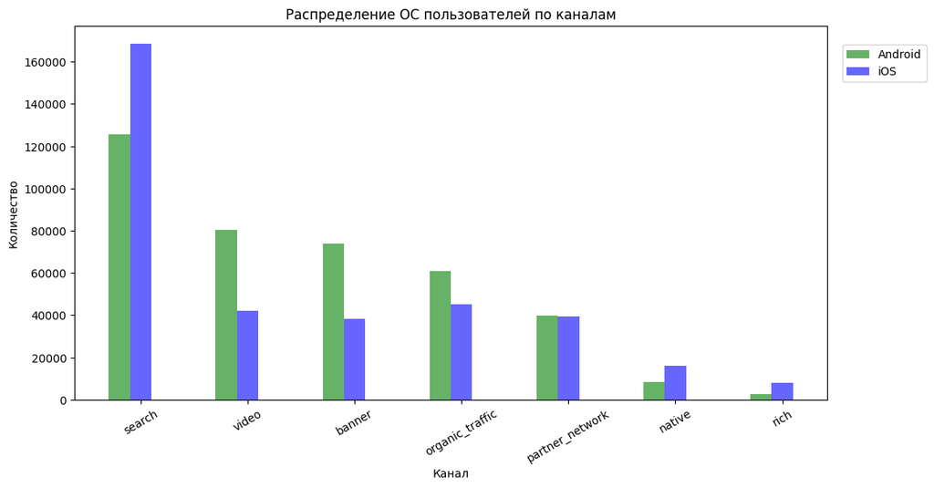

```python
display(Image(filename='data/users_os.png'))
```

Существование связи между каналом и операционной системой (хоть и слабой, но она все же есть) также показывает тепловая карта корреляций:

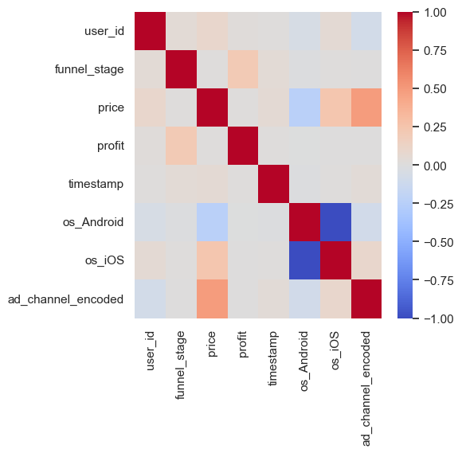

```python
display(Image(filename='data/heatmap.png'))
```

Это доказывает, что некоторые каналы показывают рекламу преимущественно пользователям одной ос, нежели другой

Поэтому возникает предположение, что если мы увеличим бюджет на каналы, с которых приходит больше пользователей iOS, сможем увеличить продажи. Соответственно, первая гипотеза, которую проверю:

Пользователи с операционной системой iOS приносят больше прибыли, чем пользователи с Android

Посмотрим на корреляции признаков profit и os

```python
df_cor = pd.read_csv('data/for_cor_factor') #подготовленный датасет без категориальных переменных из модуля 9
```

```python
stats.pearsonr(df_cor['profit'], df_cor['os_Android'])
```

```
PearsonRResult(statistic=-0.005920970748020303, pvalue=5.061619602975953e-09)
```

```python
stats.pearsonr(df_cor['profit'], df_cor['os_iOS'])
```

```
PearsonRResult(statistic=0.005920970748020303, pvalue=5.061619602975953e-09)
```

Значения статистик очень малы и указывают на то, что корреляции между этими признаками нет, а значит вид операционной системы не влияет на прибыль. Поэтому при выборе канала, рекламный бюджет которого хотим увеличить, можем не акцентировать внимание на search.

Из трех платных прибыльных каналов остаются таким образом каналы banner и partner_nerwork, затраты и прибыль которых примерно равны. К тому же эти каналы по своей сути похожи на каналы rich и native, которые являются убыточными. Поэтому предлагаю затраченные бюджеты перераспределить следующим образом: rich → banner и native → partner_network

Чтобы понять, сколько прибыли может принести дополнительный бюджет на исследуемые каналы, рассчитаю:

1. стоимость привлечения одного целевого клиента для banner и partner_network
2. возможную прибыль с этих каналов
3. сравню эти показатели с текущими данными

```python
df_b = df.groupby(['ad_channel', 'funnel_stage'], as_index = False, observed = True).agg({'price':'sum',
                                                        'profit': 'sum',
                                                        'user_id': 'nunique'})
df_b = df_b.rename(columns={'price': 'expenses',
                           'profit': 'income',
                           'user_id': 'user_count'})

df_b
```

|  | ad_channel | funnel_stage | expenses | income | user_count |
| --- | --- | --- | --- | --- | --- |
| 0 | banner | consideration | 23711.00 | 0.0 | 47422 |
| 1 | banner | intent | 3769.50 | 0.0 | 7539 |
| 2 | banner | interest | 45497.00 | 0.0 | 90994 |
| 3 | banner | purchase | 344.00 | 465814.0 | 688 |
| 4 | native | consideration | 25166.00 | 0.0 | 12583 |
| 5 | native | intent | 812.00 | 0.0 | 406 |
| 6 | native | interest | 38400.00 | 0.0 | 19200 |
| 7 | native | purchase | 72.00 | 31665.0 | 36 |
| 8 | organic_traffic | consideration | 0.00 | 0.0 | 53618 |
| 9 | organic_traffic | intent | 0.00 | 0.0 | 9079 |
| 10 | organic_traffic | interest | 0.00 | 0.0 | 77982 |
| 11 | organic_traffic | purchase | 0.00 | 370283.0 | 540 |
| 12 | partner_network | consideration | 24688.00 | 0.0 | 24688 |
| 13 | partner_network | intent | 4370.00 | 0.0 | 4370 |
| 14 | partner_network | interest | 65388.00 | 0.0 | 65388 |
| 15 | partner_network | purchase | 450.00 | 473965.0 | 450 |
| 16 | rich | consideration | 11637.50 | 0.0 | 4655 |
| 17 | rich | intent | 3052.50 | 0.0 | 1221 |
| 18 | rich | interest | 22075.00 | 0.0 | 8830 |
| 19 | rich | purchase | 52.50 | 29301.0 | 21 |
| 20 | search | consideration | 201081.00 | 0.0 | 134054 |
| 21 | search | intent | 40780.50 | 0.0 | 27187 |
| 22 | search | interest | 333831.00 | 0.0 | 222554 |
| 23 | search | purchase | 4627.50 | 2109647.0 | 3085 |
| 24 | video | consideration | 45654.00 | 0.0 | 60872 |
| 25 | video | intent | 43.50 | 0.0 | 58 |
| 26 | video | interest | 72756.00 | 0.0 | 97008 |
| 27 | video | purchase | 3.75 | 3595.0 | 5 |

```python
df_count = df_b.groupby(['ad_channel'], as_index = False, observed = True).agg({'expenses':'sum',
                                                        'income': 'sum'})
df_count = df_count.rename(columns={'expenses':'expenses_sum',
                                       'income':'income_sum'})
df_count
```

|  | ad_channel | expenses_sum | income_sum |
| --- | --- | --- | --- |
| 0 | banner | 73321.50 | 465814.0 |
| 1 | native | 64450.00 | 31665.0 |
| 2 | organic_traffic | 0.00 | 370283.0 |
| 3 | partner_network | 94896.00 | 473965.0 |
| 4 | rich | 36817.50 | 29301.0 |
| 5 | search | 580320.00 | 2109647.0 |
| 6 | video | 118457.25 | 3595.0 |

```python
#стоимость привлечения одного клиента с канала, совершившего целевое действие

CPA_banner = df_count[df_count['ad_channel'] == 'banner']['expenses_sum'].iloc[0] / df_b[(df_b['ad_channel'] == 'banner') & (df_b['funnel_stage'] == 'purchase')]['user_count'].iloc[0]
CPA_partner = df_count[df_count['ad_channel'] == 'partner_network']['expenses_sum'].iloc[0] / df_b[(df_b['ad_channel'] == 'partner_network') & (df_b['funnel_stage'] == 'purchase')]['user_count'].iloc[0]

print('Стоимость привлечения одного целевого клиента с banner:', round(CPA_banner, 2))
print('Стоимость привлечения одного целевого клиента с partner_network:', round(CPA_partner, 2))
```

```
Стоимость привлечения одного целевого клиента с banner: 106.57
Стоимость привлечения одного целевого клиента с partner_network: 210.88
```

```python
# усредненное значение прибыли, которую приносит один клиент

user_profit_banner = df_count[df_count['ad_channel'] == 'banner']['income_sum'].iloc[0] / df_b[(df_b['ad_channel'] == 'banner') & (df_b['funnel_stage'] == 'purchase')]['user_count'].iloc[0]
user_profit_partner = df_count[df_count['ad_channel'] == 'partner_network']['income_sum'].iloc[0] / df_b[(df_b['ad_channel'] == 'partner_network') & (df_b['funnel_stage'] == 'purchase')]['user_count'].iloc[0]
print('Усредненная прибыль с одного целевого клиента с banner:', round(user_profit_banner, 2))
print('Усредненная прибыль с одного целевого клиента с partner_network:', round(user_profit_partner, 2))
```

```
Усредненная прибыль с одного целевого клиента с banner: 677.06
Усредненная прибыль с одного целевого клиента с partner_network: 1053.26
```

```python
# Количество целевых клиентов, которых может принести дополнительный бюджет каналам

us_ban = round((df_count[df_count['ad_channel'] == 'rich']['expenses_sum'].iloc[0] / CPA_banner))
us_part = round((df_count[df_count['ad_channel'] == 'native']['expenses_sum'].iloc[0] / CPA_partner))

print('Количество возможных новых клиентов для banner:', us_ban)
print('Количество возможных новых клиентов для partner_network:', us_part)
```

```
Количество возможных новых клиентов для banner: 345
Количество возможных новых клиентов для partner_network: 306
```

```python
#Дополнительный доход для каналов
pr_banner = round((user_profit_banner * us_ban),2)
pr_partner = round((user_profit_partner * us_part), 2)

print('Возможный дополнительный доход с канала banner:', pr_banner)
print('Возможный дополнительный доход с канала partner_network:', pr_partner)
```

```
Возможный дополнительный доход с канала banner: 233584.06
Возможный дополнительный доход с канала partner_network: 322296.2
```

Создам датасет, по которому построю диаграмму соотношения затрат и прибыли по каналам взаимодействия, учитывая добавленные бюджеты и возможные доходы

```python
df_ch_cost = df.groupby(['ad_channel'], as_index = False, observed=True).agg({'price':'sum',
                                                                                'profit': 'sum'})
df_ch_cost = df_ch_cost.rename(columns={'price':'price_sum',
                                       'profit':'profit_sum'})

df_ch_cost
```

|  | ad_channel | price_sum | profit_sum |
| --- | --- | --- | --- |
| 0 | banner | 73321.50 | 465814.0 |
| 1 | native | 64450.00 | 31665.0 |
| 2 | organic_traffic | 0.00 | 370283.0 |
| 3 | partner_network | 94896.00 | 473965.0 |
| 4 | rich | 36817.50 | 29301.0 |
| 5 | search | 580320.00 | 2109647.0 |
| 6 | video | 118457.25 | 3595.0 |

```python
#partner_network
df_ch_cost.loc[3, 'price_sum'] = 159346.0
df_ch_cost.loc[3, 'profit_sum'] = 796261.2

#banner
df_ch_cost.loc[0, 'price_sum'] = 110139.0
df_ch_cost.loc[0, 'profit_sum'] = 699398.06

df_ch_cost = df_ch_cost.sort_values(by = 'profit_sum', ascending = False)
df_ch_cost = df_ch_cost.reset_index(drop=True)
df_ch_cost
```

|  | ad_channel | price_sum | profit_sum |
| --- | --- | --- | --- |
| 0 | search | 580320.00 | 2109647.00 |
| 1 | partner_network | 159346.00 | 796261.20 |
| 2 | banner | 110139.00 | 699398.06 |
| 3 | organic_traffic | 0.00 | 370283.00 |
| 4 | native | 64450.00 | 31665.00 |
| 5 | rich | 36817.50 | 29301.00 |
| 6 | video | 118457.25 | 3595.00 |

```python
#датасет с каналами после оптимизации

df_ch_cost = df_ch_cost.iloc[:-3]
df_ch_cost
```

|  | ad_channel | price_sum | profit_sum |
| --- | --- | --- | --- |
| 0 | search | 580320.0 | 2109647.00 |
| 1 | partner_network | 159346.0 | 796261.20 |
| 2 | banner | 110139.0 | 699398.06 |
| 3 | organic_traffic | 0.0 | 370283.00 |

Для наглядности изображу все изменения на диаграмме и рядом расположу построенную ранее диаграмму соотношений затрат и прибыли до оптимизации

```python
#график из модуля 10
fig_2 = fig_load_expenses_profit

#новый график
ad_channel = df_ch_cost.ad_channel
price_sum = df_ch_cost.price_sum
profit_sum = df_ch_cost.profit_sum

trace1 = go.Bar(x=ad_channel, y=price_sum, name='Затраты', marker_color='red', showlegend = False)
trace2 = go.Bar(x=ad_channel, y=profit_sum, name='Прибыль', marker_color='green', showlegend = False)

fig = make_subplots(rows=1, cols=2, subplot_titles=("После оптимизации", "До оптимизации"))

fig.add_trace(trace1, row=1, col=1)
fig.add_trace(trace2, row=1, col=1)

for trace in fig_2['data']:
    fig.add_trace(trace, row=1, col=2)


fig.update_layout(
    title=
    {'text':'Соотношение затрат и прибыли для каналов взаимодействия с клиентами',
    'x': 0.5,
    'y': 0.9},
    showlegend=True
)

fig.show()
```

[interactive chart not shown]

Таким образом после перераспределения бюджета каналы partner_network и banner могут принести на 68 % и 50 % прибыли соответственно